# Effect for Those Who Have Not Received Coupon in FY2019 (Sample Selection 2)

Preview

Hiroki Kato

2022-03-12

## 2019年度クーポン券配布対象外の男性に限定した分析

次に、2019年度には、クーポン券の送付対象ではないが、オンデマンドでクーポン券を受け取れる人に限定して、 ナッジ・メッセージの効果を推定する。

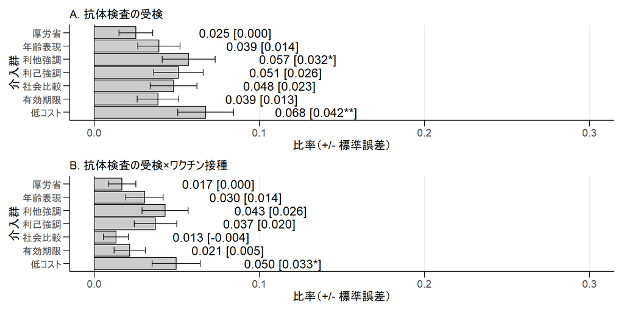

2019年度クーポン券配布対象外の男性に限定した行動に対するナッジ・メッセージの効果。注）図中の数値は各群の比率を示し、括弧内の数値はナッジ・メッセージの効果の規模を示している。効果の統計的な有意性は次の規則に従う：* p < 0.1、** p < 0.05、*** p < 0.01。

2019年度クーポン券配布対象外の男性に限定した 抗体検査とワクチン接種の線形確率モデルの推定結果

抗体検査

抗体検査×ワクチン接種

年齢表現

0.014

0.015

0.014

0.015

(0.016)

(0.017)

(0.014)

(0.014)

利他強調

0.032*

0.032*

0.026

0.026

(0.019)

(0.019)

(0.016)

(0.016)

利己強調

0.026

0.027

0.020

0.023

(0.018)

(0.018)

(0.015)

(0.015)

社会比較

0.023

0.023

－0.004

－0.003

(0.017)

(0.018)

(0.011)

(0.011)

有効期限

0.013

0.015

0.005

0.007

(0.016)

(0.017)

(0.013)

(0.013)

低コスト

0.042**

0.042**

0.033*

0.032*

(0.020)

(0.020)

(0.017)

(0.017)

Num.Obs.

1578

1578

1578

1578

R2

0.004

0.018

0.006

0.025

R2 Adj.

0.000

0.005

0.002

0.012

共変量

X

X

抗体検査受検者の動き

| ナッジ・メッセージ | サンプルサイズ | 抗体検査の受検 人数 | 抗体検査の受検 二群比較のp値 | 抗体検査の結果が陰性 人数 | 抗体検査の結果が陰性 二群比較のp値 | 陰性かつワクチンを接種 人数 | 陰性かつワクチンを接種 二群比較のp値 |
| --- | --- | --- | --- | --- | --- | --- | --- |
| 厚労省 | 238 | 6 | － | 4 | － | 4 | － |
| 年齢表現 | 230 | 9 | 0.440 | 9 | 0.143 | 7 | 1.000 |
| 利他強調 | 210 | 12 | 0.096 | 9 | 1.000 | 9 | 1.000 |
| 利己強調 | 216 | 11 | 0.215 | 8 | 1.000 | 8 | 1.000 |
| 社会比較 | 229 | 11 | 0.222 | 5 | 0.620 | 3 | 0.444 |
| 有効期限 | 233 | 9 | 0.443 | 6 | 1.000 | 5 | 1.000 |
| 低コスト | 222 | 15 | 0.042 | 13 | 0.544 | 11 | 1.000 |

注）二群比較は、厚労省メッセージ群とあるナッジ・メッセージの二群をFisherの正確検定で分析している。抗体検査の受検をアウトカムとするとき、抗体検査の受検者数に群間で差がないという帰無仮説を検定している。抗体検査の陰性者をアウトカムとするとき、抗体検査の受検者の中で陰性者の比率に群間で差がないという帰無仮説を検定している。陰性者のワクチン接種をアウトカムとするとき、陰性者の中でワクチン接種の比率に群間で差がないという帰無仮説を検定している。